# Quantifying the In-Game Impact of Counter-Strike: Global Offensive Players through Ridge Regression

## Presentation Outline

- Background
- Data Collection
- Data Preparation
- Modeling
- Results
- Discussion

## Counter-Strike: Global Offensive (CS:GO)

- First-person shooter, released in 2012
- Games feature two teams of five
  - “Terrorist” (T) versus “counter terrorist” (C)
- Games consist of two halves (max 15 rounds each)
  - Quickest possible game: 16-0
  - Longest possible (non-overtime) game: 16-14
  - T & C sides are switched each half
- Popular competitive e-sports scene
  - 2.74 million viewers in last major tournament

## Data scraping

1. Created function to scrape data from a page for a single match between two teams from HLTV (`hltv.org`)
2. Loop to apply that function multiple times for every match registered in HLTV
   - Each page on `hltv.org` features 100 matches
   - Function was iterated through over 110 pages
   - Collected data for 19034 professional games since December 3rd, 2015
     - One match may consist of multiple games (best-of-3, best-of-5 matches)

## Data preparation

- Data set split into two rows for each game
  - Each row represents one half of the game
- Percentage of rounds won by T for each half is `tWinPct`, the response variable
  - If the T side won three rounds in a half versus five for the C side, `tWinPct` equals \(3/8=0.375\)

## Data preparation (2)

- Each player represents a single explanatory variable
  - Obtained a player’s rating (\(r_i\)) for each half from `hltv.org`
    - Based on simple statistics such as kills, assists, deaths, survival rating, damage rating
  - Player on T side = \(1/r_i\) (player \(T_i\))
    - Reciprocal of \(r_i\) is taken for T side so that higher coefficient values correspond with higher impact
  - Player on C side = \(-r_i\) (player \(C_i\))
    - \(-r_i\) used for C side because better performances from the players on C side will result in the T side winning less rounds (response variable)
  - Player not playing in that game = \(0\)

## Data preparation (3)

- Each game in the dataset is played on one of 11 possible “maps”
  - A map is the arena in which a game takes place
  - Different maps may be more or less favorable to the T side
- Dummy variables introduced based on the map a game is played on
- Then, input (explanatory) matrix \(\boldsymbol{A}\) contains 2263 player variables and 11 map variables for 38068 observations
  - Each row will have 11 nonzero values: ten players and one map
- Output vector \(\boldsymbol{b}\) (`tWinPct`) contains 38068 values

## T Win Rate by Map

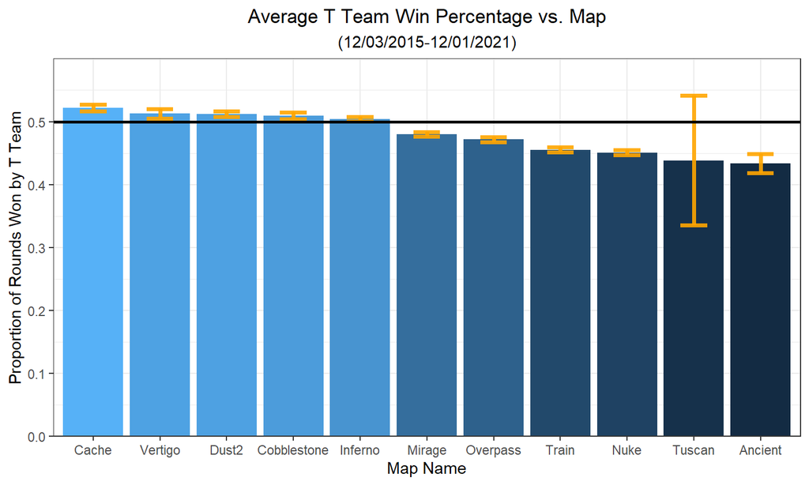

## Data preparation (4)

**Example**

- Game played between team \(A\) with players \(A_1,A_2,...,A_5\) and a team \(B\) with players \(B_1,B_2,...,B_5\) on map \(M_{10}\) of maps \(M_1,M_2,...,M_{11}\).
  - First half: Team \(A\) is on side T and wins nine rounds to six
  - Second half: Team \(B\) is on side T and wins six rounds to seven
- Then the input matrix \(\boldsymbol{A}\) would look like …

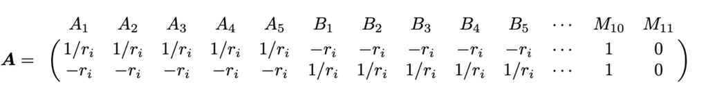

- And the output vector \(\boldsymbol{b}\) would contain two values, \(\frac{9}{15}\) and \(\frac{6}{13}\).

## Equation

- Now that we have our input matrix \(\boldsymbol{A}\) and output vector \(\boldsymbol{b}\), we look to estimate the coefficients \(\boldsymbol{x}\) such that \(\boldsymbol{W}\boldsymbol{A}\boldsymbol{x}=\boldsymbol{W}\boldsymbol{b}\)
  - \(\boldsymbol{W}\) is the weight vector - it contains 38068 values and simply represents the number of rounds played in a half
  - A 15-0 half should be weighed more than a 1-0 half although they both have the same response variable `tWinPct`

## Ridge Regression

- Method of estimating coefficients in multiple regression when there’s a high degree of collinearity among explanatory variables
- Type of regularization: introduces a penalty term that shrinks coefficients towards zero, reducing variance
- Traditional ordinary least squares (OLS) solution for \(\boldsymbol{W}\boldsymbol{A}\boldsymbol{x}=\boldsymbol{W}\boldsymbol{b}\) is \(\boldsymbol{x}=(\boldsymbol{A}^{T}\boldsymbol{W}\boldsymbol{A})^{-1}\boldsymbol{A}^{T}\boldsymbol{b}\)
- Ridge regression solution is \(\boldsymbol{x}=(\boldsymbol{A}^{T}\boldsymbol{W}\boldsymbol{A}+\lambda\boldsymbol{I})^{-1}\boldsymbol{A}^{T}\boldsymbol{W}\boldsymbol{b}\)
  - Ridge parameter (\(\lambda\)) is a constant that determines the amount of regularization
    - When \(\lambda=0\), we have the OLS solution
    - When \(\lambda=\infty\), all coefficients are equal to \(0\)

## Cross Validation

- K-fold cross validation is used to find the optimal \(\lambda\) value for the ridge regression solution

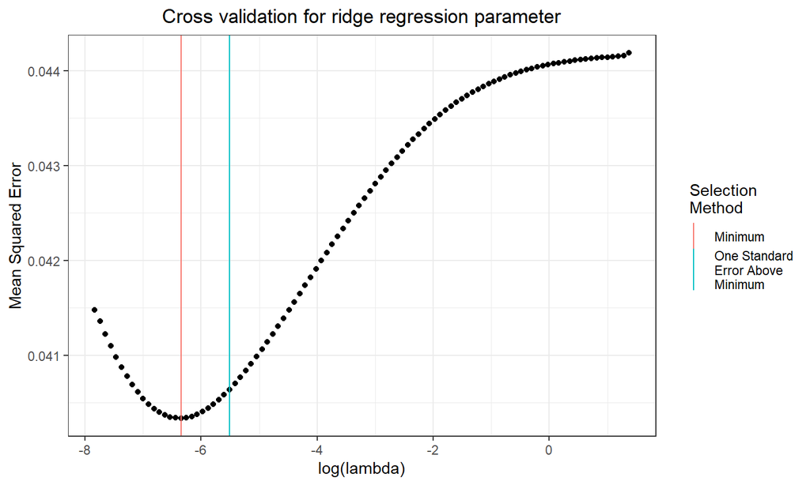

## Results

- Resulting 2274 coefficients are matched to the 2263 players and 11 maps

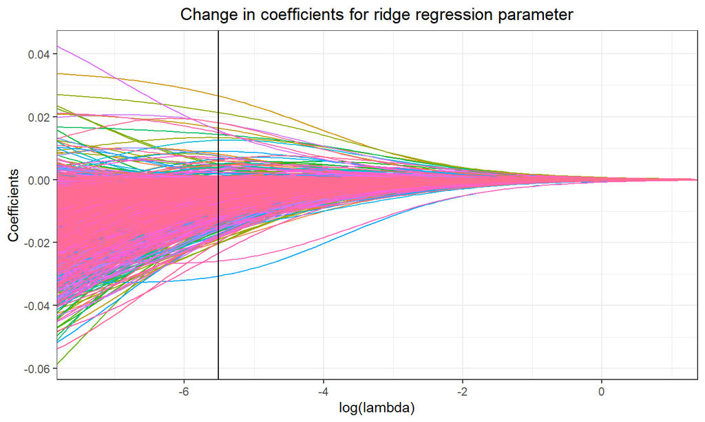

## Results (2)

Map coefficient estimates

| Map | Estimate | T Win Rate | 95% CI Lower Bound | 95% CI Upper Bound |
| --- | --- | --- | --- | --- |
| Cache | 0.0268 | 0.5217 | 0.5165 | 0.5269 |
| Vertigo | 0.0151 | 0.5126 | 0.5053 | 0.5198 |
| Dust2 | 0.0216 | 0.5121 | 0.5080 | 0.5163 |
| Cobblestone | 0.0166 | 0.5092 | 0.5038 | 0.5146 |
| Inferno | 0.0145 | 0.5043 | 0.5007 | 0.5078 |
| Mirage | -0.0058 | 0.4801 | 0.4767 | 0.4834 |
| Overpass | -0.0135 | 0.4719 | 0.4679 | 0.4759 |
| Train | -0.0257 | 0.4554 | 0.4515 | 0.4593 |
| Nuke | -0.0304 | 0.4509 | 0.4467 | 0.4551 |
| Tuscan | -0.0005 | 0.4382 | 0.3351 | 0.5413 |
| Ancient | -0.0172 | 0.4339 | 0.4189 | 0.4488 |

## Results (3)

Top ten player coefficient estimates

| Player | Games | Estimate | Rating | Rating Percentile |
| --- | --- | --- | --- | --- |
| s1mple | 1100 | 0.0180 | 1.28 | 0.9960 |
| ZywOo | 649 | 0.0180 | 1.28 | 0.9960 |
| sh1ro | 325 | 0.0155 | 1.23 | 0.9919 |
| device | 1198 | 0.0134 | 1.19 | 0.9879 |
| Magisk | 1193 | 0.0125 | 1.12 | 0.9555 |
| NiKo | 1241 | 0.0090 | 1.20 | 0.9899 |
| B1T | 158 | 0.0083 | 1.08 | 0.8765 |
| Qikert | 692 | 0.0077 | 1.05 | 0.7976 |
| El1an | 339 | 0.0077 | 1.14 | 0.9757 |
| syrsoN | 628 | 0.0071 | 1.09 | 0.8927 |

## Model estimates vs. player statistics

[figure not shown]

## Model estimates vs. player statistics

Weighted (on games played) correlation matrix of player rating, win rate, and model estimate

|  | win.pct | estimate | rating |
| --- | --- | --- | --- |
| win.pct | 1.000 | 0.609 | 0.485 |
| estimate | 0.609 | 1.000 | 0.658 |
| rating | 0.485 | 0.658 | 1.000 |

## Discussion

- Our player evaluation framework combines both contribution to team winning & individual performance
- A similar framework can be used in the future for predictive work
  - Can a similar methodology be used to predict the outcome of CS:GO games? Or can it be used to predict the future performance of CS:GO players?
- Limitation: using a single variable for each player means that a single coefficient estimates their value even if their value fluctuated over the six years studied
  - Perhaps analyze the effect of age on a CS:GO player’s performance and weigh their ‘peak years’ higher